# Not Reading

Khalil Haji

March 20, 2019

## Reflection:

For this assignment, I chose to analyze a biography of Ezra Abbot. Ezra Abbot, as I understand, was a biblical scholar at Harvard Divinity School in the 1800s. The biography I found is put together as a series of addresses and notes from various professors, including a preface from Abbot himself. I chose Abbot as the last name seems to be a notable family in Boston with multiple notable Abbot’s available to study.

Before analyzing Abbot’s biography, I conducted some textual analysis of the autobiography of Malcolm X. Out of the chapters we read, religion played a significant role in the autobiography of Malcolm X and the textual analysis of the entire book shows this to be the case. As Abbot was a biblical scholar, it is natural that a book about him would also contain a significant amount of religious terminology. In analyzing Malcolm X’s word cloud, I found that aside from racial terms and the word “Malcolm”, the majority of terms related to either Islam or Christianity. Abbot’s word cloud on the other hand contains a mix of academic words like “university” mixed in with a significant but not overwhelming amount of religious words such as “divine”, “god”, and “sacred”. I was interested in the usage of each subject’s name in their respective books. Malcolm X, an autobiography, mentions the name “Malcolm” a relatively large number of times. Ezra Abbot’s biography, not written by Ezra himself contains a proportionally smaller number of mentions of Ezra’s name than Malcolm X. I was somewhat surprised by this. Intuitively, an autobiography written in the first person, would refer to the subject in the first person as well. Perhaps the writing style of Ezra’s biography simply happens to employ the use of more pronouns.

After analyzing the word clouds, I generated word clouds of the bigrams of each text. I filtered out all the bigrams where both words were stop words to avoid phrases such as “of the” and “in the”. In Abbot’s biography, the biggest bigrams were Abbot’s name including his title. This was somewhat confusing given my earlier observation of Abbot’s name appearing proportionally less often when compared to Malcolm X. Aside from his name, most of the bigrams consist of academic terms, similar to the word cloud with individual words. Many of the terms include words relating to books such as “library” and “textual criticism”. Before removing the stop-words, I realized that the word clouds for the two texts were not the same. Given the difference in the time period between the two texts, I wonder if literary style has to do with what stop-words show up more often. Perhaps there are grammatical constructs that were more prevalent in the 19th century than in the 20th. I would imagine there are obvious differences between 20th century American literature and something like Shakespeare, however, the difference between these two pieces is more subtle. I believe that comparing two works of different genres such as a novel and a poem would yield greatly different stop-word counts because grammar rules for poems are more loosely defined.

Next, I compared word counts between the two texts. When plotting frequencies of words between the two text, there was a clear concentration of biblical and Christian words under the line x = y. This is an indication that Ezra’s biography goes into detail about his work in biblical studies. Malcolm X contained many race-related words that point to the role of race in the book. From the chapters I read of Malcolm X, I found this to be accurate.

One major obstacle was the formatting of the two books. Malcolm X was arranged neatly into chapters, however, the version of the Ezra biography did not have clear delimiters between chapters. I was forced to manually add a label for each chapter in order to separate the text by chapters for sentiment analysis. Aside from the inconsistent chapter formatting, the text was digitized by Google, however, there were many random symbols throughout the file which may have affected the accuracy of my analysis. I wonder how a more thorough cleaning of the data than I was able to perform would affect the results. While I enjoyed experimenting with different representations of the two texts that I chose, I don’t believe that treating literature as data can accurately portray the tone or content of any particular text. Perhaps this is because I don’t have extensive experience with topic modeling or sentiment analysis. Someone who knows exactly what to look for and more importantly has done this sort of analysis on text they are extremely familiar with might have a better idea of what to look for when analyzing any particular piece of literature.

The word clouds and comparison of counts, however, did give me some idea of what is covered by Abbot’s biography. Words relating to a particular field of interest, in this case religion, seems to be a clear indication of general topics in a text. However, as I previously stated, the tone and emotion of the text seems to be lost in converting the text to data. Books, as a form of information, when converted to data lose some meaning. It is difficult to then extract that lost meaning just by looking at the data.

### Word clouds with stop words included:

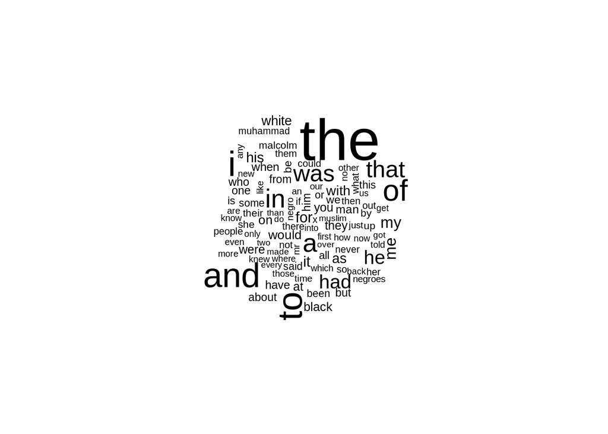

```r
malcolm = tibble(paragraph = read_file("malcolm.txt"))
malcolm %>%
  unnest_tokens(word,paragraph) %>%
  group_by(word) %>% summarize(count = n()) %>%
  with(wordcloud(word,count,max.words = 100))
```

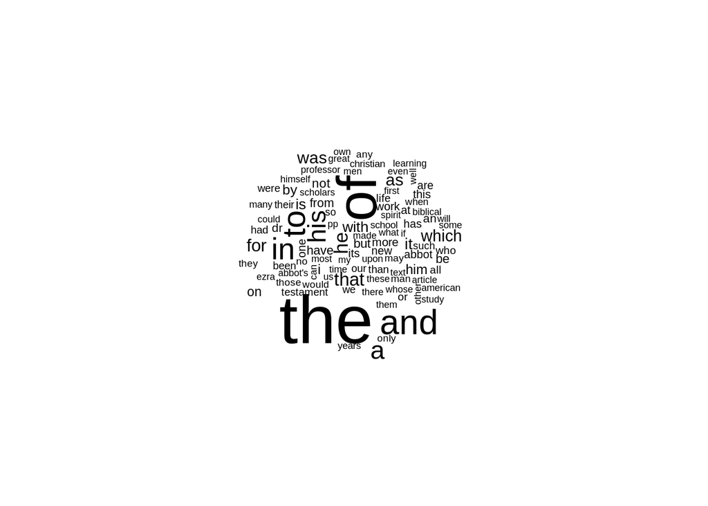

```r
ezra = tibble(paragraph = read_file("ezra.txt"))
ezra %>%
  unnest_tokens(word,paragraph) %>%
  group_by(word) %>% summarize(count = n()) %>%
  with(wordcloud(word,count,max.words = 100))
```

### Word clouds with stop words omitted:

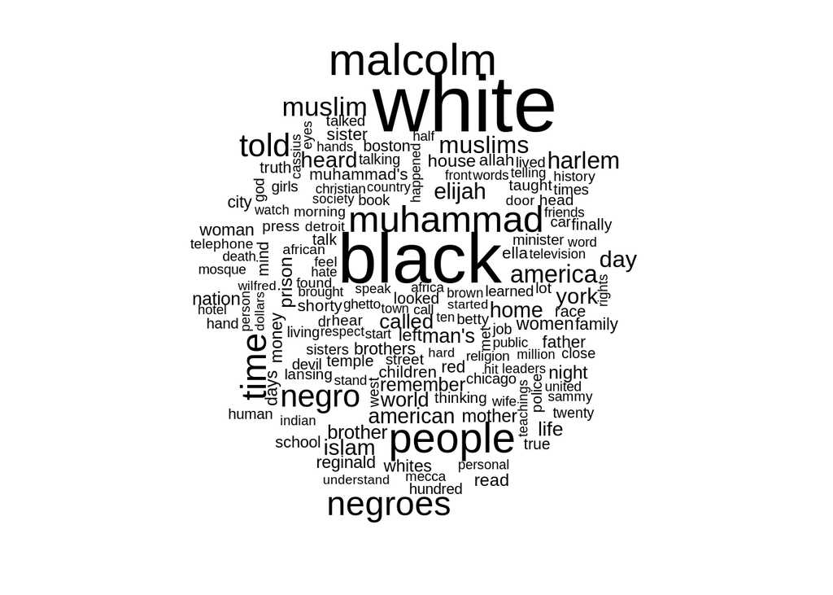

```r
malcolm %>%
  unnest_tokens(word,paragraph) %>%
  group_by(word) %>% summarize(count = n()) %>%
  anti_join(stop_words) %>% #<- This is the only change to our little program from before.
  with(wordcloud(word, count, max.words = 150))
```

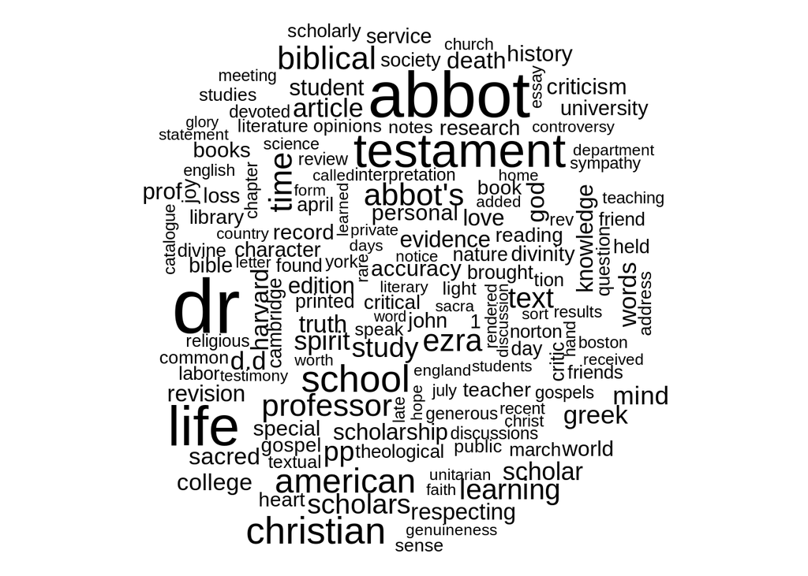

```r
ezra %>%
  unnest_tokens(word,paragraph) %>%
  group_by(word) %>% summarize(count = n()) %>%
  anti_join(stop_words) %>% #<- This is the only change to our little program from before.
  with(wordcloud(word, count, max.words = 150))
```

### Bigrams displayed as word clouds:

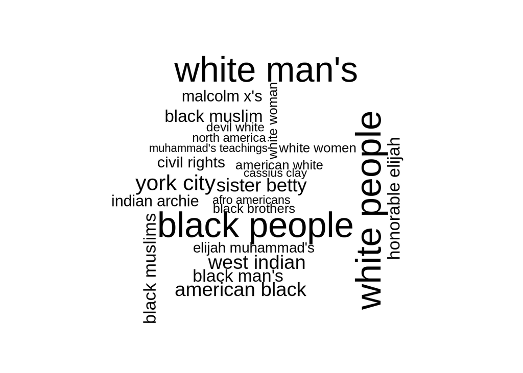

```r
 malcolm %>%
    unnest_tokens(bigram, paragraph, token = "ngrams", n = 2) %>%
    separate(bigram, c("word1", "word2"), sep = " ") %>%
    filter(!word1 %in% stop_words$word,
           !word2 %in% stop_words$word) %>%
  unite(bigram, word1, word2, sep = " ") %>%
  group_by(bigram) %>% summarize(count = n()) %>%
  arrange(-count) %>%
  with(wordcloud(bigram, count, max.words=25))
```

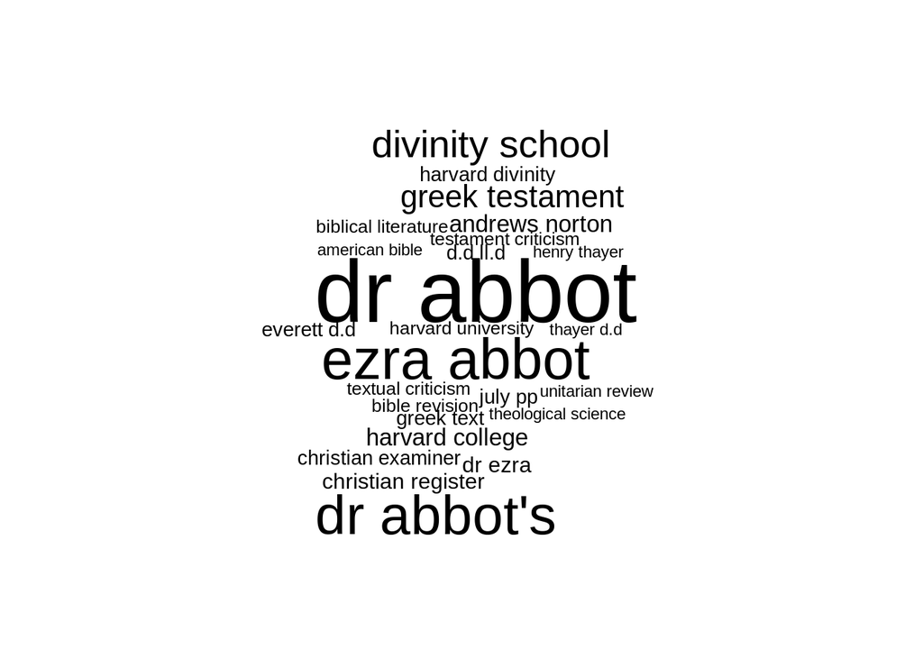

```r
 ezra %>%
    unnest_tokens(bigram, paragraph, token = "ngrams", n = 2) %>%
    separate(bigram, c("word1", "word2"), sep = " ") %>%
    filter(!word1 %in% stop_words$word,
           !word2 %in% stop_words$word) %>%
  unite(bigram, word1, word2, sep = " ") %>%
  group_by(bigram) %>% summarize(count = n()) %>%
  arrange(-count) %>%
  with(wordcloud(bigram, count, max.words=25))
```

### The comparison of word counts on a plot:

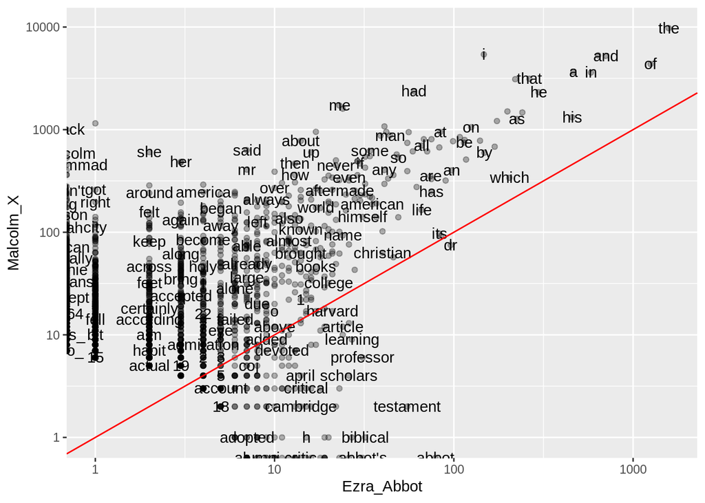

```r
our_books = tibble(
  title = c("Malcolm_X","Ezra_Abbot"),
  text = c(read_file("malcolm.txt"), read_file("ezra.txt"))
)

our_words = our_books %>% unnest_tokens(word,text)

our_books %>%
  unnest_tokens(word,text,token = "ngrams", n=1) %>%
  group_by(title,word) %>%
  summarize(count=n()) %>%
  spread(title,count,fill=0) %>% # Just like above
  filter(Ezra_Abbot + Malcolm_X > 6) %>%  # Only words that appear 6 times.
  ggplot() +
  aes(x=Ezra_Abbot,y=Malcolm_X,label=word) +
  geom_point(alpha=.3) +
  geom_text(check_overlap = TRUE) +
  scale_x_log10() +
  scale_y_log10() +
  geom_abline(color = "red")
```